# Modeling Swire Coca Cola

Author

ANISH KHAIRNAR

Published

December 6, 2024

## Introduction & Setup:

Swire Coca-Cola faces challenges in unplanned machine downtimes leading to operational inefficiencies. This project aims to develop predictive maintenance models to anticipate machine failures, allowing for proactive maintenance actions.

The objective of this project is to build a predictive maintenance model for Swire Coca-Cola, aimed at reducing unplanned machine downtimes and enhancing overall operational efficiency. At present, the company faces substantial financial losses and productivity declines due to unexpected equipment failures.

To overcome these challenges, Swire Coca-Cola seeks to implement a predictive maintenance solution. By analyzing historical data from the Internal Warehouse Controller (IWC) system, the goal is to identify patterns in machine failures, forecast future downtimes, and ensure that necessary parts are available in advance. The solution aims to minimize unplanned downtimes, optimize machine reliability, and improve production capacity while reducing financial losses.

This exploratory data analysis (EDA) serves as the foundation for building the predictive model. Through detailed analysis of machine maintenance records, downtime logs, and operational data, we will uncover the key factors contributing to machine breakdowns. These insights will help shape a data-driven, proactive maintenance approach, enabling Swire Coca-Cola to shift from reactive to predictive maintenance, improve operational efficiency, and better meet production targets.

### Overview of Predictive Maintenance for Swire Coca-Cola

Predictive maintenance leverages historical machine data to predict when maintenance should be performed. This helps reduce downtime and extend the life of equipment.

### Key Objectives:

1. Improve on the baseline model’s performance.
2. Develop robust features as identified in the EDA.
3. Evaluate different models and select the one best suited to solve the business problem.
- Implement predictive models to forecast machine failures.
- Enable preventive actions based on predictions to enhance operational efficiency.

### Importing Libraries

```r
# Load necessary libraries
library(ggplot2)
library(dplyr)
library(tidyr)
library(lubridate)
library(scales)
library(dplyr)
library(ggplot2)
library(caret)
library(randomForest)
```

### Import Dataset

```r
# Load the dataset
data <- read.csv("IWC_Work_Orders_Extract.csv")

# Display the first few rows of the dataset
head(data)
```

```
   ORDER_ID PLANT_ID PRODUCTION_LOCATION EXECUTION_START_DATE
1 705642457     G812                ROMA           2024-05-04
2 704191697     G812                ROMA           2022-09-13
3 704466547     G812                ROMA           2022-12-21
4 703834477     G812                ROMA           2022-07-04
5 704661125     G291               MONZA           2023-03-15
6 704948720     G291               MONZA           2023-09-08
  EXECUTION_FINISH_DATE ACTUAL_START_TIME ACTUAL_FINISH_TIME
1            2024-05-12      06:00:00.000       23:04:08.000
2            2022-09-13      06:00:00.000       17:17:24.000
3            2022-12-21      07:00:00.000       07:00:00.000
4            2022-07-04      06:00:00.000       06:00:00.000
5            2023-03-15      07:00:00.000       07:00:00.000
6            2023-09-08      07:00:00.000       07:00:00.000
  ACTUAL_WORK_IN_MINUTES MAINTENANCE_PLAN MAINTENANCE_ITEM
```

[output cut: 48 more lines]

The dataset gives an in-depth glance at how Swire Coca-Cola manages maintenance across various plants and production sites. It contains important details like maintenance dates, how long they last, whether they are planned or unplanned, and thorough descriptions of the equipment involved. The data covers multiple years, making it possible to analyze trends over time. Important columns such as ACTUAL_WORK_IN_MINUTES and MAINTENANCE_TYPE_DESCRIPTION provide valuable insights into the nature and extent of maintenance activities.

Some interesting patterns stand out from this first look. A lot of entries fall under unplanned, corrective maintenance, which hints at a possibly reactive way of handling equipment maintenance. The dataset includes a range of machinery, and you’ll notice that conveyor systems show up quite often in the sample. This detailed dataset will play a key role in examining maintenance trends, spotting equipment that needs regular care, and possibly revealing chances to move from reactive to proactive maintenance approaches. This shift could help minimize unexpected downtime and enhance overall operational efficiency.

## Understanding the Data

### Checking the Structure of the Data

```r
# Checking the structure of the data
str(data)
```

```
'data.frame':   1427264 obs. of  25 variables:
 $ ORDER_ID                       : num  7.06e+08 7.04e+08 7.04e+08 7.04e+08 7.05e+08 ...
 $ PLANT_ID                       : chr  "G812" "G812" "G812" "G812" ...
 $ PRODUCTION_LOCATION            : chr  "ROMA" "ROMA" "ROMA" "ROMA" ...
 $ EXECUTION_START_DATE           : chr  "2024-05-04" "2022-09-13" "2022-12-21" "2022-07-04" ...
 $ EXECUTION_FINISH_DATE          : chr  "2024-05-12" "2022-09-13" "2022-12-21" "2022-07-04" ...
 $ ACTUAL_START_TIME              : chr  "06:00:00.000" "06:00:00.000" "07:00:00.000" "06:00:00.000" ...
 $ ACTUAL_FINISH_TIME             : chr  "23:04:08.000" "17:17:24.000" "07:00:00.000" "06:00:00.000" ...
 $ ACTUAL_WORK_IN_MINUTES         : num  390 420 30 60 120 18 480 30 30 30 ...
 $ MAINTENANCE_PLAN               : chr  "" "" "" "" ...
 $ MAINTENANCE_ITEM               : int  NA NA NA NA NA 40534 NA NA NA NA ...
 $ MAINTENANCE_ACTIVITY_TYPE      : chr  "Unplanned" "Unplanned" "Unplanned" "Unplanned" ...
 $ ORDER_DESCRIPTION              : chr  "L2 GEARBOX LEAK (SEE ATTACHED)" "LINE 3 CONVEYOR AT CAN CODER" "BROKEN CONVEYOR RAIL" "LINE 3 CONVEYOR" ...
 $ MAINTENANCE_TYPE_DESCRIPTION   : chr  "Corrective Maintenance Order" "Corrective Maintenance Order" "Corrective Maintenance Order" "Corrective Maintenance Order" ...
 $ FUNCTIONAL_LOC                 : chr  "G812-PRD-L15-L03-L030-020" "G812-PRD-L15-L03-L030-020" "G812-PRD-L15-L03-L030-020" "G812-PRD-L15-L03-L030-020" ...
 $ FUNCTIONAL_AREA_NODE_1_MODIFIED: chr  "PRODUCTION" "PRODUCTION" "PRODUCTION" "PRODUCTION" ...
 $ FUNCTIONAL_AREA_NODE_2_MODIFIED: chr  "G812 PRD FILLER_ROTARY_CAN" "G812 PRD FILLER_ROTARY_CAN" "G812 PRD FILLER_ROTARY_CAN" "G812 PRD FILLER_ROTARY_CAN" ...
 $ FUNCTIONAL_AREA_NODE_3_MODIFIED: chr  "G812 PRD FILLER_ROTARY_CAN LINE 3" "G812 PRD FILLER_ROTARY_CAN LINE 3" "G812 PRD FILLER_ROTARY_CAN LINE 3" "G812 PRD FILLER_ROTARY_CAN LINE 3" ...
 $ FUNCTIONAL_AREA_NODE_4_MODIFIED: chr  "CONVEYOR" "CONVEYOR" "CONVEYOR" "CONVEYOR" ...
 $ FUNCTIONAL_AREA_NODE_5_MODIFIED: chr  "FULL CAN CONVEYOR" "FULL CAN CONVEYOR" "FULL CAN CONVEYOR" "FULL CAN CONVEYOR" ...
 $ EQUIPMENT_ID                   : int  300126812 300126812 300126812 300126812 300001088 300001088 300001088 300001033 300001033 300001033 ...
 $ EQUIPMENT_DESC                 : chr  "FULL CAN CONVEYOR (FC41B)" "FULL CAN CONVEYOR (FC41B)" "FULL CAN CONVEYOR (FC41B)" "FULL CAN CONVEYOR (FC41B)" ...
 $ EQUIP_CAT_DESC                 : chr  "Machines" "Machines" "Machines" "Machines" ...
 $ EQUIP_START_UP_DATE            : chr  "2020-04-22" "2020-04-22" "2020-04-22" "2020-04-22" ...
 $ EQUIP_VALID_FROM               : chr  "2020-02-10" "2020-02-10" "2020-02-10" "2020-02-10" ...
 $ EQUIP_VALID_TO                 : chr  "9999-12-31" "9999-12-31" "9999-12-31" "9999-12-31" ...
```

```r
# Summary statistics
summary(data)
```

```
    ORDER_ID           PLANT_ID         PRODUCTION_LOCATION
 Min.   :1.000e+08   Length:1427264     Length:1427264
 1st Qu.:4.023e+08   Class :character   Class :character
 Median :7.044e+08   Mode  :character   Mode  :character
 Mean   :4.561e+10
 3rd Qu.:1.002e+09
 Max.   :9.000e+11

 EXECUTION_START_DATE EXECUTION_FINISH_DATE ACTUAL_START_TIME
 Length:1427264       Length:1427264        Length:1427264
 Class :character     Class :character      Class :character
 Mode  :character     Mode  :character      Mode  :character




 ACTUAL_FINISH_TIME ACTUAL_WORK_IN_MINUTES MAINTENANCE_PLAN   MAINTENANCE_ITEM
 Length:1427264     Min.   :     0.0       Length:1427264     Min.   : 39801
 Class :character   1st Qu.:    12.0       Class :character   1st Qu.: 41046
 Mode  :character   Median :    48.0       Mode  :character   Median :112995
                    Mean   :    88.6                          Mean   :115847
                    3rd Qu.:    90.0                          3rd Qu.:134702
                    Max.   :330184.8                          Max.   :346352
                                                              NA's   :1274670
 MAINTENANCE_ACTIVITY_TYPE ORDER_DESCRIPTION  MAINTENANCE_TYPE_DESCRIPTION
 Length:1427264            Length:1427264     Length:1427264
 Class :character          Class :character   Class :character
 Mode  :character          Mode  :character   Mode  :character




 FUNCTIONAL_LOC     FUNCTIONAL_AREA_NODE_1_MODIFIED
 Length:1427264     Length:1427264
 Class :character   Class :character
 Mode  :character   Mode  :character




```

[output cut: 13 more lines]

```



  EQUIPMENT_ID       EQUIPMENT_DESC     EQUIP_CAT_DESC     EQUIP_START_UP_DATE
 Min.   :200087110   Length:1427264     Length:1427264     Length:1427264
 1st Qu.:300009161   Class :character   Class :character   Class :character
 Median :300017751   Mode  :character   Mode  :character   Mode  :character
 Mean   :300260910
 3rd Qu.:300026939
 Max.   :400029000
 NA's   :1135469
 EQUIP_VALID_FROM   EQUIP_VALID_TO
 Length:1427264     Length:1427264
 Class :character   Class :character
 Mode  :character   Mode  :character
```

The summary statistics showcase some key aspects of the data. For example, the ACTUAL_WORK_IN_MINUTES spans from 0 to 330,184.8 minutes, with a median of 48 minutes, indicating a broad range of durations for maintenance tasks. The MAINTENANCE_ITEM field shows a significant amount of NA values (1,274,670), which suggests there might be some data quality concerns or that this information was recorded optionally. The EQUIPMENT_ID field has some NA values, so we might need to look into that a bit more. The dataset covers several years, as shown by the EXECUTION_START_DATE field, which makes it possible to analyze trends over the long term. This dataset opens up plenty of chances to dive deep into maintenance trends, equipment performance, and how efficiently things are running at Swire Coca-Cola’s facilities.

### Checking for Missing Data

```r
# Check for empty strings in the data
empty_strings <- sapply(data, function(x) sum(x == ""))
print(empty_strings)
```

```
                       ORDER_ID                        PLANT_ID
                              0                               0
            PRODUCTION_LOCATION            EXECUTION_START_DATE
                              0                               0
          EXECUTION_FINISH_DATE               ACTUAL_START_TIME
                              0                               0
             ACTUAL_FINISH_TIME          ACTUAL_WORK_IN_MINUTES
                              0                               0
               MAINTENANCE_PLAN                MAINTENANCE_ITEM
                        1274670                              NA
      MAINTENANCE_ACTIVITY_TYPE               ORDER_DESCRIPTION
                              0                         1135497
   MAINTENANCE_TYPE_DESCRIPTION                  FUNCTIONAL_LOC
                        1135469                         1135482
FUNCTIONAL_AREA_NODE_1_MODIFIED FUNCTIONAL_AREA_NODE_2_MODIFIED
                        1137147                         1144857
FUNCTIONAL_AREA_NODE_3_MODIFIED FUNCTIONAL_AREA_NODE_4_MODIFIED
                        1168573                         1189691
FUNCTIONAL_AREA_NODE_5_MODIFIED                    EQUIPMENT_ID
                        1425084                              NA
                 EQUIPMENT_DESC                  EQUIP_CAT_DESC
                        1347817                         1347817
            EQUIP_START_UP_DATE                EQUIP_VALID_FROM
                        1347817                         1347817
                 EQUIP_VALID_TO
                        1347817
```

```r
# Identify missing data (NA's) columns
cols_with_na <- colnames(data)[colSums(is.na(data)) > 0]
print("Columns with NA values:")
```

```
[1] "Columns with NA values:"
```

```r
print(cols_with_na)
```

```
[1] "MAINTENANCE_ITEM" "EQUIPMENT_ID"
```

The above code identifies empty strings and columns with missing values (NAs). Columns such as MAINTENANCE_ITEM and EQUIPMENT_ID are identified as having substantial missing data, reinforcing the need to address this issue for accurate analysis.

```r
# Replacing empty strings with na
data[data == ""] <- NA
```

This code replaces all empty strings with NA values to standardize the dataset.

```r
# Check for missing data
missing_data <- data.frame(Feature = names(data), MissingCount = sapply(data, function(x) sum(is.na(x))))
missing_data
```

```
                                                        Feature MissingCount
ORDER_ID                                               ORDER_ID            0
PLANT_ID                                               PLANT_ID            0
PRODUCTION_LOCATION                         PRODUCTION_LOCATION            0
EXECUTION_START_DATE                       EXECUTION_START_DATE            0
EXECUTION_FINISH_DATE                     EXECUTION_FINISH_DATE            0
ACTUAL_START_TIME                             ACTUAL_START_TIME            0
ACTUAL_FINISH_TIME                           ACTUAL_FINISH_TIME            0
ACTUAL_WORK_IN_MINUTES                   ACTUAL_WORK_IN_MINUTES            0
MAINTENANCE_PLAN                               MAINTENANCE_PLAN      1274670
MAINTENANCE_ITEM                               MAINTENANCE_ITEM      1274670
MAINTENANCE_ACTIVITY_TYPE             MAINTENANCE_ACTIVITY_TYPE            0
ORDER_DESCRIPTION                             ORDER_DESCRIPTION      1135497
MAINTENANCE_TYPE_DESCRIPTION       MAINTENANCE_TYPE_DESCRIPTION      1135469
FUNCTIONAL_LOC                                   FUNCTIONAL_LOC      1135482
FUNCTIONAL_AREA_NODE_1_MODIFIED FUNCTIONAL_AREA_NODE_1_MODIFIED      1137147
FUNCTIONAL_AREA_NODE_2_MODIFIED FUNCTIONAL_AREA_NODE_2_MODIFIED      1144857
FUNCTIONAL_AREA_NODE_3_MODIFIED FUNCTIONAL_AREA_NODE_3_MODIFIED      1168573
FUNCTIONAL_AREA_NODE_4_MODIFIED FUNCTIONAL_AREA_NODE_4_MODIFIED      1189691
FUNCTIONAL_AREA_NODE_5_MODIFIED FUNCTIONAL_AREA_NODE_5_MODIFIED      1425084
EQUIPMENT_ID                                       EQUIPMENT_ID      1135469
EQUIPMENT_DESC                                   EQUIPMENT_DESC      1347817
EQUIP_CAT_DESC                                   EQUIP_CAT_DESC      1347817
EQUIP_START_UP_DATE                         EQUIP_START_UP_DATE      1347817
EQUIP_VALID_FROM                               EQUIP_VALID_FROM      1347817
EQUIP_VALID_TO                                   EQUIP_VALID_TO      1347817
```

### Visualizing Missing Data

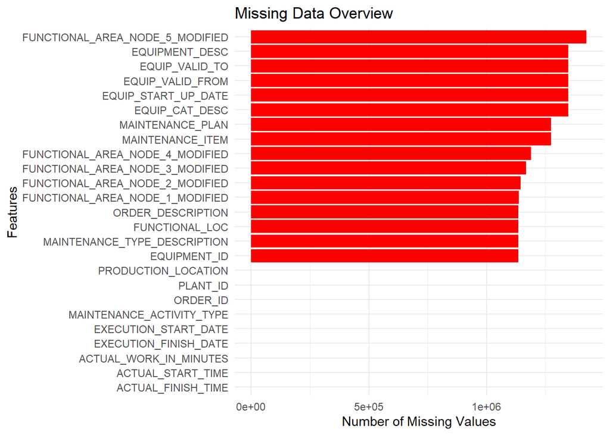

```r
# Visualize missing data
ggplot(missing_data, aes(x=reorder(Feature, MissingCount), y=MissingCount)) +
  geom_bar(stat='identity', fill='red') +
  coord_flip() +
  labs(title='Missing Data Overview', x='Features', y='Number of Missing Values') +
  theme_minimal()
```

### Handling Missing Values for Numeric Data

```r
# 1. First handle MAINTENANCE_PLAN
data$MAINTENANCE_PLAN[is.na(data$MAINTENANCE_PLAN)] <- "Unplanned"

# 2. Handle descriptive fields
data$ORDER_DESCRIPTION[is.na(data$ORDER_DESCRIPTION)] <- "Unknown"
data$EQUIPMENT_DESC[is.na(data$EQUIPMENT_DESC)] <- "Unknown"
data$EQUIP_CAT_DESC[is.na(data$EQUIP_CAT_DESC)] <- "Unknown"
data$FUNCTIONAL_LOC[is.na(data$FUNCTIONAL_LOC)] <- "Unknown"
data$MAINTENANCE_TYPE_DESCRIPTION[is.na(data$MAINTENANCE_TYPE_DESCRIPTION)] <- "Unknown"

# 3. Handle functional area nodes
data$FUNCTIONAL_AREA_NODE_1_MODIFIED[is.na(data$FUNCTIONAL_AREA_NODE_1_MODIFIED)] <- "Unknown"
data$FUNCTIONAL_AREA_NODE_2_MODIFIED[is.na(data$FUNCTIONAL_AREA_NODE_2_MODIFIED)] <- "Unknown"  # Fixed
data$FUNCTIONAL_AREA_NODE_3_MODIFIED[is.na(data$FUNCTIONAL_AREA_NODE_3_MODIFIED)] <- "Unknown"  # Fixed
data$FUNCTIONAL_AREA_NODE_4_MODIFIED[is.na(data$FUNCTIONAL_AREA_NODE_4_MODIFIED)] <- "Unknown"  # Fixed
data$FUNCTIONAL_AREA_NODE_5_MODIFIED[is.na(data$FUNCTIONAL_AREA_NODE_5_MODIFIED)] <- "Unknown"  # Fixed

# 4. Handle equipment dates if needed
data$EQUIP_START_UP_DATE[is.na(data$EQUIP_START_UP_DATE)] <- "Unknown"
data$EQUIP_VALID_FROM[is.na(data$EQUIP_VALID_FROM)] <- "Unknown"
data$EQUIP_VALID_TO[is.na(data$EQUIP_VALID_TO)] <- "Unknown"
```

For the missing values (NAs) in the MAINTENANCE_PLAN column, they’re being filled in with “Unplanned” based on the case description, it makes sense to assume that if we don’t know the maintenance plan, it was likely an unplanned maintenance activity. This helps keep the data more consistent and prevents any issues with missing values during the analysis. We did not handle missing values in equipment id and maintenance item column through imputation because item, and id can not be assigned random values based on the median or mode of the column.

For other columns—like ORDER_DESCRIPTION, EQUIPMENT_DESC, and various FUNCTIONAL_AREA fields—any missing values are replaced with “Unknown”. This is a simple way of handling missing data. Instead of leaving them blank or removing the rows, we just mark them as “Unknown”. This makes sure we don’t lose any records and that the data stays usable for further analysis or modeling.

### Final Check for Missing Values

```r
# Check for missing values after imputation
missing_after_imputation <- sapply(data, function(x) sum(is.na(x)))
print(missing_after_imputation)
```

```
                       ORDER_ID                        PLANT_ID
                              0                               0
            PRODUCTION_LOCATION            EXECUTION_START_DATE
                              0                               0
          EXECUTION_FINISH_DATE               ACTUAL_START_TIME
                              0                               0
             ACTUAL_FINISH_TIME          ACTUAL_WORK_IN_MINUTES
                              0                               0
               MAINTENANCE_PLAN                MAINTENANCE_ITEM
                              0                         1274670
      MAINTENANCE_ACTIVITY_TYPE               ORDER_DESCRIPTION
                              0                               0
   MAINTENANCE_TYPE_DESCRIPTION                  FUNCTIONAL_LOC
                              0                               0
FUNCTIONAL_AREA_NODE_1_MODIFIED FUNCTIONAL_AREA_NODE_2_MODIFIED
                              0                               0
FUNCTIONAL_AREA_NODE_3_MODIFIED FUNCTIONAL_AREA_NODE_4_MODIFIED
                              0                               0
FUNCTIONAL_AREA_NODE_5_MODIFIED                    EQUIPMENT_ID
                              0                         1135469
                 EQUIPMENT_DESC                  EQUIP_CAT_DESC
                              0                               0
            EQUIP_START_UP_DATE                EQUIP_VALID_FROM
                              0                               0
                 EQUIP_VALID_TO
                              0
```

### Visual Verification- After Imputation Visualization

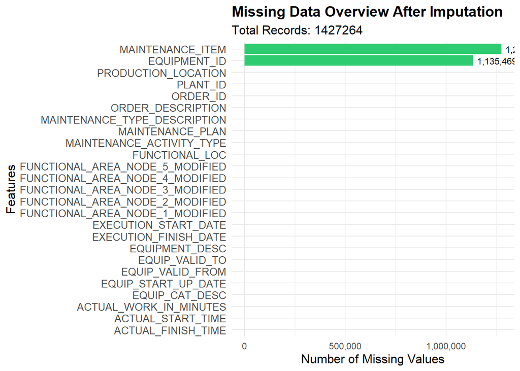

```r
# Visualize missing data after handling
# Create missing data summary
missing_data_after <- data.frame(
  Feature = names(data),
  MissingCount = sapply(data, function(x) sum(is.na(x)))
)

# Create visualization
ggplot(missing_data_after, aes(x = reorder(Feature, MissingCount), y = MissingCount)) +
  geom_bar(stat = 'identity', fill = '#2ecc71') +  # Using a nice green color
  coord_flip() +
  labs(
    title = 'Missing Data Overview After Imputation',
    subtitle = paste('Total Records:', nrow(data)),
    x = 'Features',
    y = 'Number of Missing Values'
  ) +
  theme_minimal() +
  theme(
    plot.title = element_text(face = "bold", size = 14),
    plot.subtitle = element_text(size = 12),
    axis.text.y = element_text(size = 10),
    axis.title = element_text(size = 12)
  ) +
  scale_y_continuous(labels = scales::comma) +
  geom_text(
    aes(label = scales::comma(MissingCount)),
    hjust = -0.1,
    size = 3,
    data = subset(missing_data_after, MissingCount > 0)
  )
```

The graphs shows few columns that have not been imputed for the missing values because of the limitation of handing them through statistical imputation. Other columns like maintenance plan, order description are being handled.

### Summary Statistics Check

```r
# Summary statistics after handling missing values
summary(data)
```

```
    ORDER_ID           PLANT_ID         PRODUCTION_LOCATION
 Min.   :1.000e+08   Length:1427264     Length:1427264
 1st Qu.:4.023e+08   Class :character   Class :character
 Median :7.044e+08   Mode  :character   Mode  :character
 Mean   :4.561e+10
 3rd Qu.:1.002e+09
 Max.   :9.000e+11

 EXECUTION_START_DATE EXECUTION_FINISH_DATE ACTUAL_START_TIME
 Length:1427264       Length:1427264        Length:1427264
 Class :character     Class :character      Class :character
 Mode  :character     Mode  :character      Mode  :character




 ACTUAL_FINISH_TIME ACTUAL_WORK_IN_MINUTES MAINTENANCE_PLAN   MAINTENANCE_ITEM
 Length:1427264     Min.   :     0.0       Length:1427264     Min.   : 39801
 Class :character   1st Qu.:    12.0       Class :character   1st Qu.: 41046
 Mode  :character   Median :    48.0       Mode  :character   Median :112995
                    Mean   :    88.6                          Mean   :115847
                    3rd Qu.:    90.0                          3rd Qu.:134702
                    Max.   :330184.8                          Max.   :346352
                                                              NA's   :1274670
 MAINTENANCE_ACTIVITY_TYPE ORDER_DESCRIPTION  MAINTENANCE_TYPE_DESCRIPTION
 Length:1427264            Length:1427264     Length:1427264
 Class :character          Class :character   Class :character
 Mode  :character          Mode  :character   Mode  :character




 FUNCTIONAL_LOC     FUNCTIONAL_AREA_NODE_1_MODIFIED
 Length:1427264     Length:1427264
 Class :character   Class :character
 Mode  :character   Mode  :character




```

[output cut: 13 more lines]

```



  EQUIPMENT_ID       EQUIPMENT_DESC     EQUIP_CAT_DESC     EQUIP_START_UP_DATE
 Min.   :200087110   Length:1427264     Length:1427264     Length:1427264
 1st Qu.:300009161   Class :character   Class :character   Class :character
 Median :300017751   Mode  :character   Mode  :character   Mode  :character
 Mean   :300260910
 3rd Qu.:300026939
 Max.   :400029000
 NA's   :1135469
 EQUIP_VALID_FROM   EQUIP_VALID_TO
 Length:1427264     Length:1427264
 Class :character   Class :character
 Mode  :character   Mode  :character
```

## General Exploration of the Dataset

### 1. What is the average time taken to complete different types of maintenance?

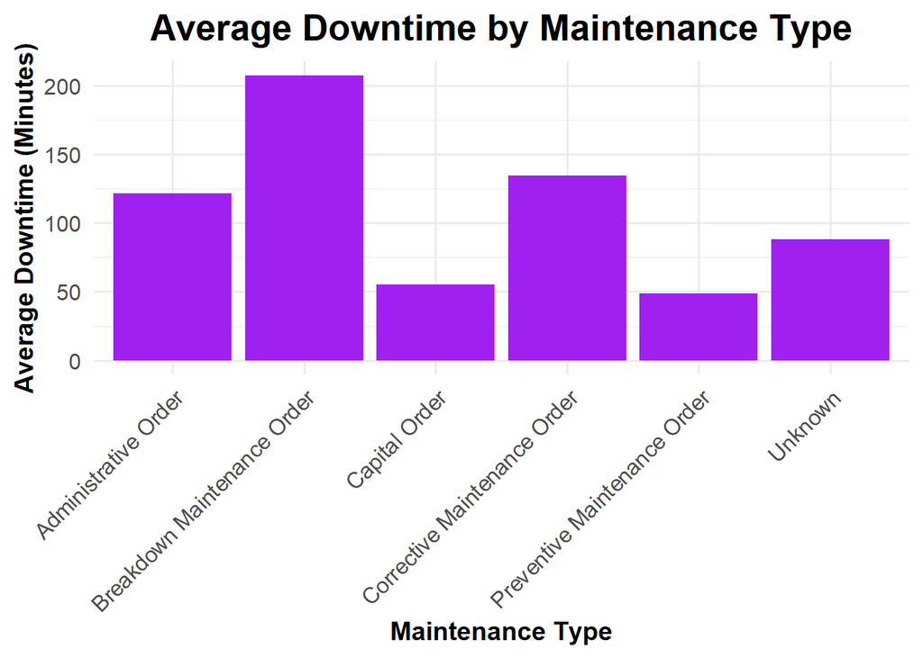

```r
# Average downtime by maintenance type
avg_downtime <- data %>%
  group_by(MAINTENANCE_TYPE_DESCRIPTION) %>%
  summarise(avg_downtime = mean(ACTUAL_WORK_IN_MINUTES, na.rm = TRUE), .groups = "drop")  # Handle NAs

# Plot with adjustments for better readability
ggplot(avg_downtime, aes(x = MAINTENANCE_TYPE_DESCRIPTION, y = avg_downtime)) +
  geom_bar(stat = "identity", fill = "purple") +
  labs(
    title = "Average Downtime by Maintenance Type",
    x = "Maintenance Type",
    y = "Average Downtime (Minutes)"
  ) +
  theme_minimal(base_size = 15) +  # Base font size for better readability
  theme(
    plot.title = element_text(hjust = 0.5, size = 20, face = "bold"),  # Center title, increase size
    axis.title.x = element_text(size = 14, face = "bold"),  # Bold x-axis title
    axis.title.y = element_text(size = 14, face = "bold"),  # Bold y-axis title
    axis.text.x = element_text(angle = 45, hjust = 1, size = 12),  # Rotate x-axis labels for better visibility
    axis.text.y = element_text(size = 12)  # Increase y-axis text size for readability
  )
```

### 2. Machine Failure Prediction on Entire Machine Fleet

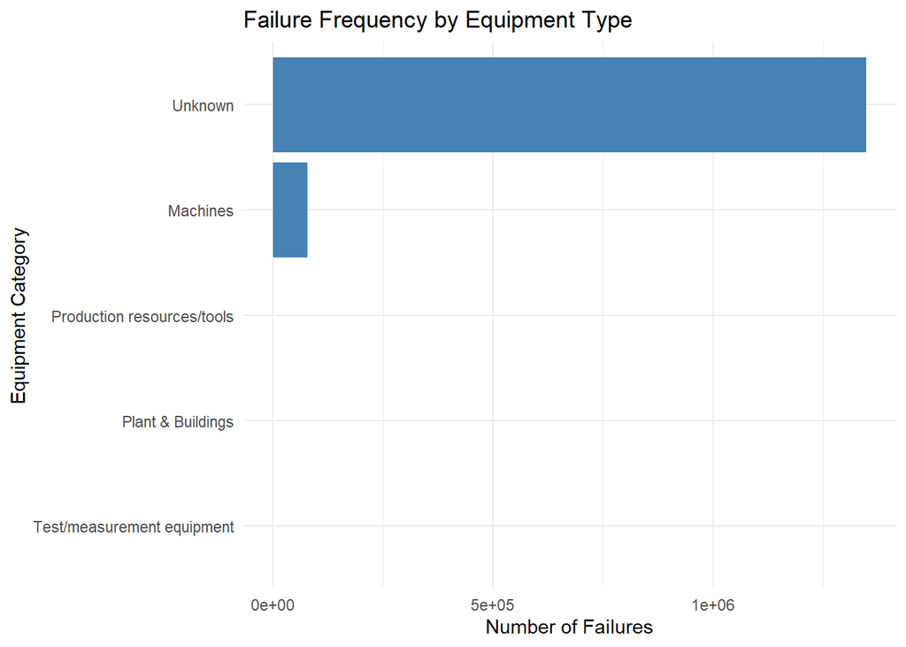

```r
# Failure frequency by equipment type
equipment_failures <- data %>%
  group_by(EQUIP_CAT_DESC) %>%
  summarise(
    failure_count = n(),
    avg_downtime = mean(ACTUAL_WORK_IN_MINUTES, na.rm = TRUE)
  ) %>%
  arrange(desc(failure_count))

ggplot(equipment_failures, aes(x = reorder(EQUIP_CAT_DESC, failure_count), y = failure_count)) +
  geom_bar(stat = "identity", fill = "steelblue") +
  coord_flip() +
  labs(
    title = "Failure Frequency by Equipment Type",
    x = "Equipment Category",
    y = "Number of Failures"
  ) +
  theme_minimal()
```

The majority of our failures are labeled as “Unknown” in our maintenance records, which honestly makes it impossible to identify which specific types of equipment are causing us the most trouble. While we can see some failures recorded under “Machines” category, it’s such a small portion compared to the “Unknown” entries that we can’t draw any meaningful conclusions about equipment-specific issues.The difference between the “Unknown” category and everything else really highlights that we have a serious data quality issue here, rather than an equipment-specific problem.

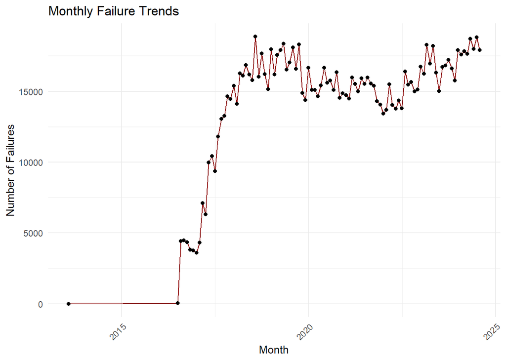

```r
# Monthly failure trends
data$month_year <- floor_date(as.Date(data$EXECUTION_START_DATE), "month")

monthly_failures <- data %>%
  group_by(month_year) %>%
  summarise(failure_count = n())

ggplot(monthly_failures, aes(x = month_year, y = failure_count)) +
  geom_line(color = "darkred") +
  geom_point() +
  labs(
    title = "Monthly Failure Trends",
    x = "Month",
    y = "Number of Failures"
  ) +
  theme_minimal() +
  theme(axis.text.x = element_text(angle = 45, hjust = 1))
```

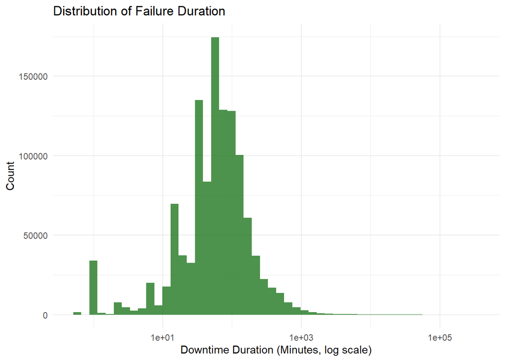

```r
# Distribution of Failure Duration
ggplot(data, aes(x = ACTUAL_WORK_IN_MINUTES)) +
  geom_histogram(bins = 50, fill = "darkgreen", alpha = 0.7) +
  scale_x_log10() +
  labs(
    title = "Distribution of Failure Duration",
    x = "Downtime Duration (Minutes, log scale)",
    y = "Count"
  ) +
  theme_minimal()
```

### 3.Machine Failure Prediction for High Maintenance Frequency

#### High-Maintenance Equipment Analysis

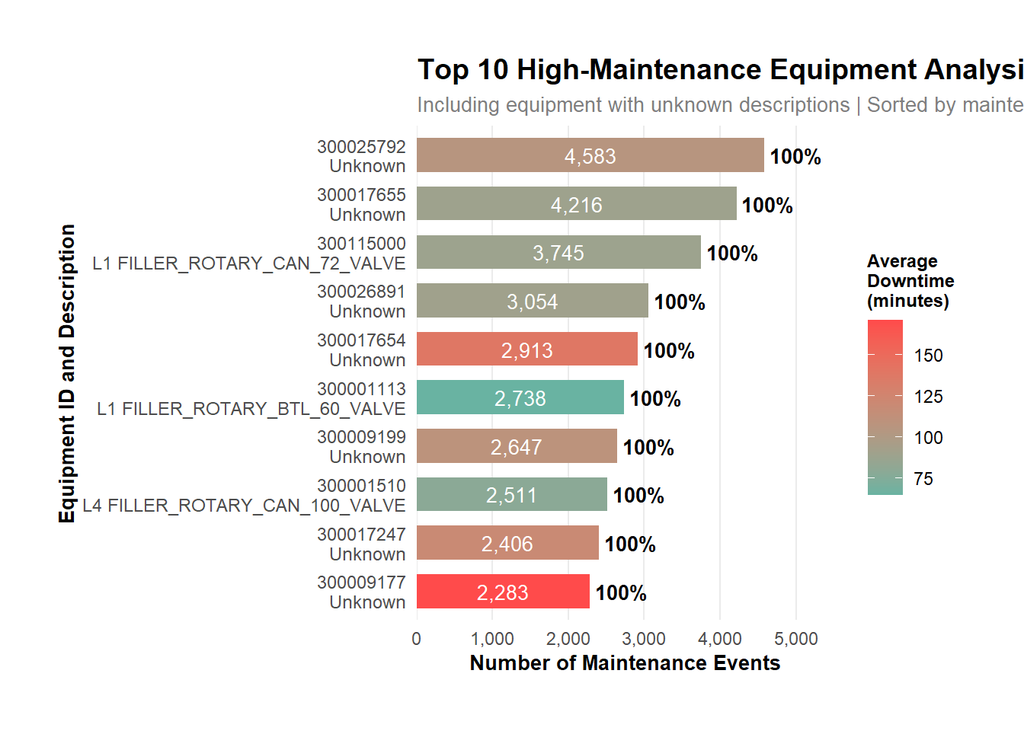

```r
# Create analysis for top 10 machines
high_maintenance_machines <- data %>%
  filter(!is.na(EQUIPMENT_ID)) %>%
  group_by(EQUIPMENT_ID, EQUIPMENT_DESC) %>%
  summarise(
    maintenance_count = n(),
    total_downtime = sum(ACTUAL_WORK_IN_MINUTES, na.rm = TRUE),
    avg_downtime = mean(ACTUAL_WORK_IN_MINUTES, na.rm = TRUE),
    maintenance_types = n_distinct(MAINTENANCE_TYPE_DESCRIPTION)
  ) %>%
  arrange(desc(maintenance_count)) %>%
  head(10)

# Calculate percentages for context
high_maintenance_machines <- high_maintenance_machines %>%
  mutate(
    pct_of_total = maintenance_count / sum(maintenance_count) * 100,
    label = paste0(
      "ID: ", EQUIPMENT_ID, "\n",
      ifelse(EQUIPMENT_DESC == "Unknown", "", paste0(EQUIPMENT_DESC, "\n")),
      "Count: ", format(maintenance_count, big.mark = ","), "\n",
      "Avg Downtime: ", round(avg_downtime, 1), " mins"
    )
  )

# Create enhanced visualization
ggplot(high_maintenance_machines,
       aes(x = reorder(paste0(EQUIPMENT_ID, "\n", EQUIPMENT_DESC), maintenance_count),
           y = maintenance_count)) +
  geom_bar(stat = "identity",
           aes(fill = avg_downtime),
           width = 0.7) +
  geom_text(aes(label = paste0(round(pct_of_total, 1), "%")),
            hjust = -0.1,
            size = 3.5,
            fontface = "bold") +
  geom_text(aes(label = format(maintenance_count, big.mark = ","),
                y = maintenance_count/2),
            color = "white",
            size = 3.5) +
  scale_fill_gradient(low = "#69b3a2",
                     high = "#FF4B4B",
                     name = "Average\nDowntime\n(minutes)") +
  labs(
    title = "Top 10 High-Maintenance Equipment Analysis",
    subtitle = "Including equipment with unknown descriptions | Sorted by maintenance frequency",
    x = "Equipment ID and Description",
    y = "Number of Maintenance Events"
  ) +
  coord_flip() +
  theme_minimal() +
  theme(
    plot.title = element_text(size = 14, face = "bold"),
    plot.subtitle = element_text(size = 10, color = "gray50"),
    axis.title.x = element_text(size = 10, face = "bold"),
    axis.title.y = element_text(size = 10, face = "bold"),
    axis.text.y = element_text(size = 9),
    legend.position = "right",
    legend.title = element_text(size = 9, face = "bold"),
    panel.grid.major.y = element_blank(),
    panel.grid.minor = element_blank(),
    plot.margin = unit(c(1, 1, 1, 1), "cm")  # Fixed margin specification
  ) +
  scale_y_continuous(
    expand = expansion(mult = c(0, 0.2)),
    labels = scales::comma
  )
```

```r
# Create detailed summary table
maintenance_summary <- high_maintenance_machines %>%
  select(
    EQUIPMENT_ID,
    EQUIPMENT_DESC,
    maintenance_count,
    avg_downtime,
    total_downtime,
    maintenance_types,
    pct_of_total
  ) %>%
  arrange(desc(maintenance_count)) %>%
  mutate(
    avg_downtime = round(avg_downtime, 1),
    total_downtime = round(total_downtime, 1),
    pct_of_total = round(pct_of_total, 2)
  )

# Print summary table
print("Detailed Maintenance Summary for Top 10 Equipment:")
```

```
[1] "Detailed Maintenance Summary for Top 10 Equipment:"
```

```r
print(maintenance_summary)
```

```
# A tibble: 10 × 7
# Groups:   EQUIPMENT_ID [10]
   EQUIPMENT_ID EQUIPMENT_DESC     maintenance_count avg_downtime total_downtime
          <int> <chr>                          <int>        <dbl>          <dbl>
 1    300025792 Unknown                         4583        106.         484506
 2    300017655 Unknown                         4216         89.3        376677
 3    300115000 L1 FILLER_ROTARY_…              3745         88.6        331877.
 4    300026891 Unknown                         3054         90.6        276620.
 5    300017654 Unknown                         2913        139.         404194.
 6    300001113 L1 FILLER_ROTARY_…              2738         64.6        176932.
 7    300009199 Unknown                         2647        109.         288932.
 8    300001510 L4 FILLER_ROTARY_…              2511         79.1        198628.
 9    300017247 Unknown                         2406        119.         287204.
10    300009177 Unknown                         2283        171          390295.
# ℹ 2 more variables: maintenance_types <int>, pct_of_total <dbl>
```

Looking at our maintenance equipment analysis, we can see some clear patterns across our top maintenance-heavy machines. The first visualization shows that equipment ID 300025792 has the highest number of maintenance events at 4,583, followed closely by 300017655 with 4,216 events. While many of these high-maintenance machines are labeled as “Unknown”, we can identify some specific equipment like the L1 FILLER_ROTARY_CAN_72_VALVE which has 3,745 maintenance events. This suggests we might need better equipment labeling in our system.

#### Maintenance Type Distribution Analysis for High-End Equipment

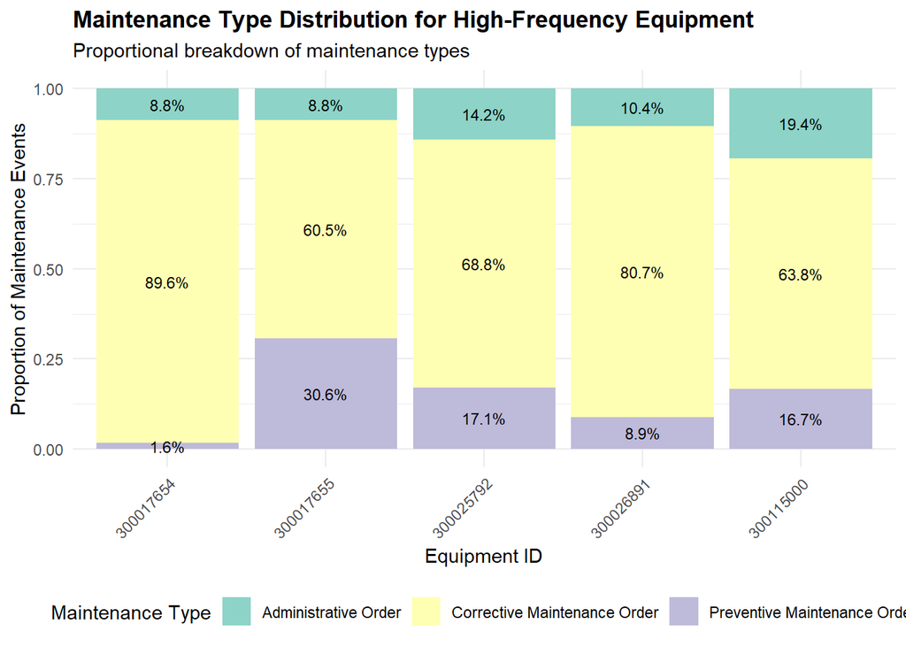

```r
# Maintenance Type Distribution Analysis
maintenance_type_dist <- data %>%
  filter(EQUIPMENT_ID %in% head(high_maintenance_machines$EQUIPMENT_ID, 5)) %>%
  group_by(EQUIPMENT_ID, MAINTENANCE_TYPE_DESCRIPTION) %>%
  summarise(
    count = n(),
    avg_duration = mean(ACTUAL_WORK_IN_MINUTES)/60  # Convert to hours
  ) %>%
  mutate(pct = count/sum(count) * 100) %>%
  ungroup()

# Maintenance Type Distribution
ggplot(maintenance_type_dist,
       aes(x = factor(EQUIPMENT_ID), y = count, fill = MAINTENANCE_TYPE_DESCRIPTION)) +
  geom_bar(stat = "identity", position = "fill") +
  geom_text(aes(label = sprintf("%.1f%%", pct)),
            position = position_fill(vjust = 0.5),
            size = 3,
            check_overlap = TRUE) +
  scale_fill_brewer(palette = "Set3", name = "Maintenance Type") +
  labs(
    title = "Maintenance Type Distribution for High-Frequency Equipment",
    subtitle = "Proportional breakdown of maintenance types",
    x = "Equipment ID",
    y = "Proportion of Maintenance Events"
  ) +
  theme_minimal() +
  theme(
    legend.position = "bottom",
    plot.title = element_text(face = "bold"),
    axis.text.x = element_text(angle = 45, hjust = 1)
  )
```

This visualization breaks down the types of maintenance being performed on our top 5 most frequently maintained equipment. What’s particularly interesting is that Corrective Maintenance Orders make up the majority of maintenance events across all equipment, ranging from about 60% to nearly 90%. For example, equipment ID 300017654 shows that almost 90% of its maintenance is corrective, with very little preventive maintenance. This might indicate a reactive rather than proactive maintenance approach.

#### Downtime Analysis

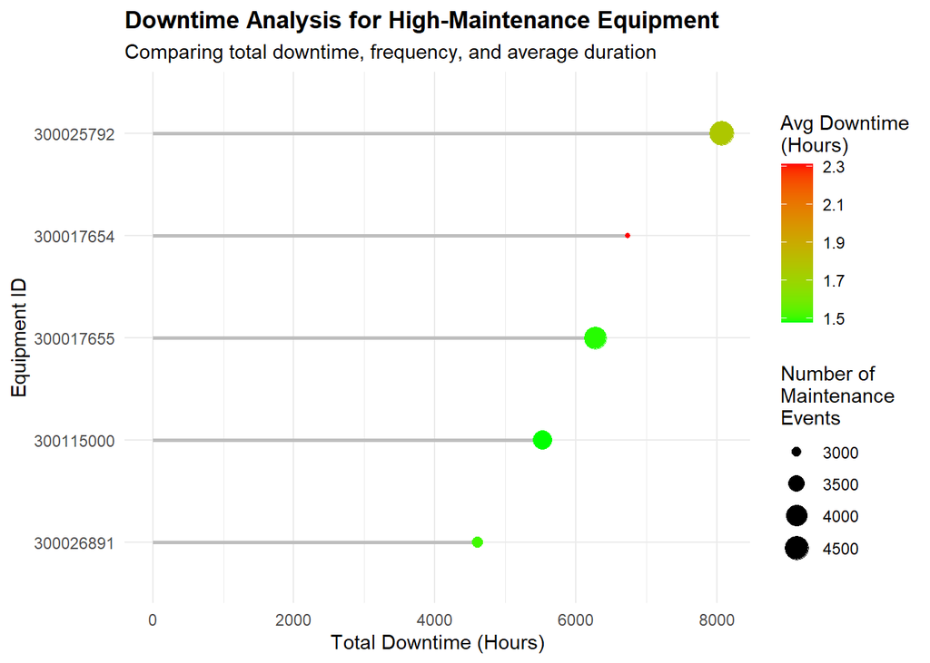

```r
downtime_analysis <- data %>%
  filter(EQUIPMENT_ID %in% head(high_maintenance_machines$EQUIPMENT_ID, 5)) %>%
  group_by(EQUIPMENT_ID) %>%
  summarise(
    total_downtime = sum(ACTUAL_WORK_IN_MINUTES)/60,  # Convert to hours
    avg_downtime = mean(ACTUAL_WORK_IN_MINUTES)/60,
    max_downtime = max(ACTUAL_WORK_IN_MINUTES)/60,
    maintenance_count = n(),
    downtime_per_event = total_downtime/maintenance_count
  ) %>%
  arrange(desc(total_downtime))

# Comparative Downtime Analysis
ggplot(downtime_analysis) +
  geom_segment(aes(x = reorder(factor(EQUIPMENT_ID), total_downtime),
                   xend = reorder(factor(EQUIPMENT_ID), total_downtime),
                   y = 0,
                   yend = total_downtime),
              color = "gray", size = 1) +
  geom_point(aes(x = reorder(factor(EQUIPMENT_ID), total_downtime),
                 y = total_downtime,
                 size = maintenance_count,
                 color = avg_downtime)) +
  scale_color_gradient(low = "green", high = "red", name = "Avg Downtime\n(Hours)") +
  scale_size_continuous(name = "Number of\nMaintenance\nEvents") +
  coord_flip() +
  labs(
    title = "Downtime Analysis for High-Maintenance Equipment",
    subtitle = "Comparing total downtime, frequency, and average duration",
    x = "Equipment ID",
    y = "Total Downtime (Hours)"
  ) +
  theme_minimal() +
  theme(
    legend.position = "right",
    plot.title = element_text(face = "bold")
  )
```

This visualization compares the total downtime hours with maintenance frequency and average duration. We can see that while some equipment has a high number of maintenance events, they don’t necessarily have the highest total downtime. The equipment with ID 300025792 stands out with around 8,000 total downtime hours, which is significantly higher than the others. The varying dot sizes and colors help us understand that some equipment might have fewer but longer maintenance events, while others have more frequent but shorter maintenance periods.

### 4. Machine Failure Prediction by Location

#### Maintenance Distribution by Production Location

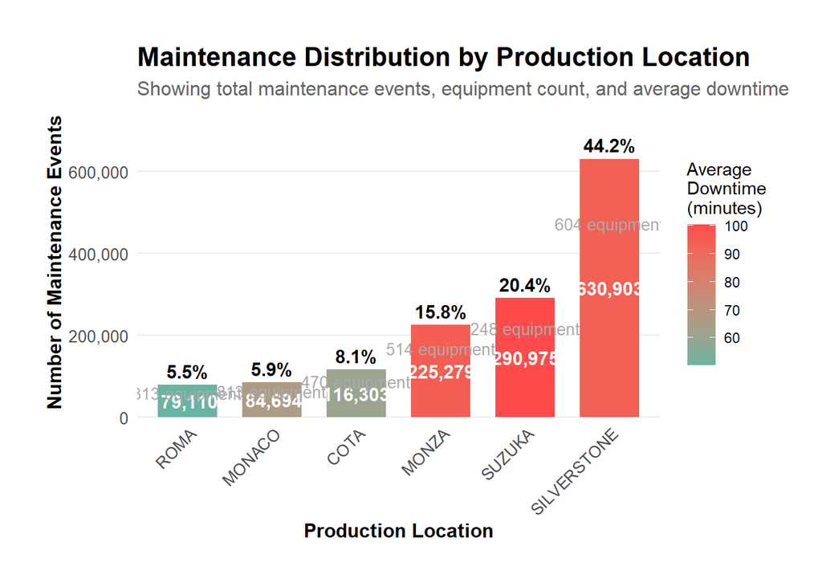

```r
# Create location analysis summary
location_maintenance <- data %>%
  group_by(PRODUCTION_LOCATION) %>%
  summarise(
    total_maintenance = n(),
    total_downtime = sum(ACTUAL_WORK_IN_MINUTES, na.rm = TRUE),
    avg_downtime = mean(ACTUAL_WORK_IN_MINUTES, na.rm = TRUE),
    unique_equipment = n_distinct(EQUIPMENT_ID),
    maintenance_per_equipment = total_maintenance/unique_equipment
  ) %>%
  arrange(desc(total_maintenance)) %>%
  mutate(
    pct_of_total = total_maintenance/sum(total_maintenance) * 100,
    downtime_hours = total_downtime/60
  )

# Create enhanced visualization
ggplot(location_maintenance,
       aes(x = reorder(PRODUCTION_LOCATION, total_maintenance),
           y = total_maintenance)) +
  # Main bars for maintenance count
  geom_bar(stat = "identity",
           aes(fill = avg_downtime),
           width = 0.7) +
  # Add text for total maintenance events
  geom_text(aes(label = format(total_maintenance, big.mark = ",")),
            position = position_stack(vjust = 0.5),
            color = "white",
            size = 4,
            fontface = "bold") +
  # Add text for percentage
  geom_text(aes(label = sprintf("%.1f%%", pct_of_total),
                y = total_maintenance),
            vjust = -0.5,
            size = 4,
            fontface = "bold") +
  # Add text for equipment count
  geom_text(aes(label = sprintf("%d equipment", unique_equipment),
                y = total_maintenance/2),
            position = position_stack(vjust = 1.5),
            color = "darkgrey",
            size = 3.5) +
  # Customize colors
  scale_fill_gradient(
    low = "#69b3a2",
    high = "#FF4B4B",
    name = "Average\nDowntime\n(minutes)"
  ) +
  # Labels and theme
  labs(
    title = "Maintenance Distribution by Production Location",
    subtitle = "Showing total maintenance events, equipment count, and average downtime",
    x = "Production Location",
    y = "Number of Maintenance Events"
  ) +
  theme_minimal() +
  theme(
    plot.title = element_text(size = 16, face = "bold"),
    plot.subtitle = element_text(size = 12, color = "grey40"),
    axis.title.x = element_text(size = 12, face = "bold"),
    axis.title.y = element_text(size = 12, face = "bold"),
    axis.text.x = element_text(size = 10, angle = 45, hjust = 1),
    axis.text.y = element_text(size = 10),
    legend.position = "right",
    panel.grid.major.x = element_blank(),
    panel.grid.minor = element_blank(),
    plot.margin = unit(c(1, 1, 1, 1), "cm")
  ) +
  # Adjust scale to accommodate labels
  scale_y_continuous(
    labels = scales::comma,
    expand = expansion(mult = c(0, 0.2))
  )
```

```r
# Print detailed statistics
location_stats <- location_maintenance %>%
  select(
    PRODUCTION_LOCATION,
    total_maintenance,
    unique_equipment,
    maintenance_per_equipment,
    downtime_hours,
    pct_of_total
  ) %>%
  arrange(desc(total_maintenance)) %>%
  mutate(
    maintenance_per_equipment = round(maintenance_per_equipment, 1),
    downtime_hours = round(downtime_hours, 1),
    pct_of_total = round(pct_of_total, 2)
  )

print(location_stats)
```

```
# A tibble: 6 × 6
  PRODUCTION_LOCATION total_maintenance unique_equipment maintenance_per_equip…¹
  <chr>                           <int>            <int>                   <dbl>
1 SILVERSTONE                    630903              604                   1044.
2 SUZUKA                         290975              248                   1173.
3 MONZA                          225279              514                    438.
4 COTA                           116303              470                    248.
5 MONACO                          84694              813                    104.
6 ROMA                            79110              313                    253.
# ℹ abbreviated name: ¹maintenance_per_equipment
# ℹ 2 more variables: downtime_hours <dbl>, pct_of_total <dbl>
```